# Untitled

## R code6:Bootstrap

```r
# Drawing ECDF (경험적 누적 분포함수, emprical cumulative distribution function)
# 서로다른 표본들의 분포 비교시 많이 사용함, 각 집단의 백분위 추정 목적
n<-1000
x<-rnorm(n)
# 표준 정규분포를 따르는 1000개의 샘플에 대한 누적분포를 나타내는 함수
F <- ecdf(x)
summary(F)
```

```
## Empirical CDF:     1000 unique values with summary
##      Min.   1st Qu.    Median      Mean   3rd Qu.      Max.
## -3.281144 -0.648905 -0.000414  0.013128  0.682825  3.009906
```

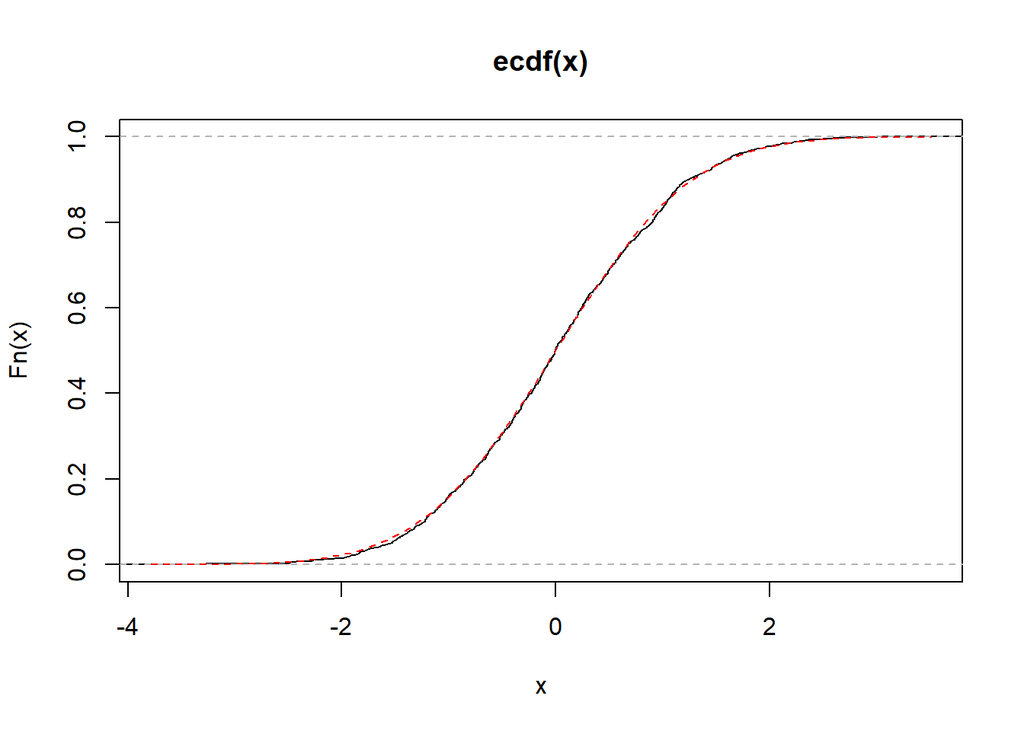

```r
x11();plot(F)
#ECDF랑 표준정규분포의 누적분포함수랑 비슷하게 그려지더라
x11();plot(F, verticals= TRUE, do.points = FALSE)
curve(pnorm, lty=2,add=TRUE,col="red")           #정규분포의 누적분포함수의 값
```

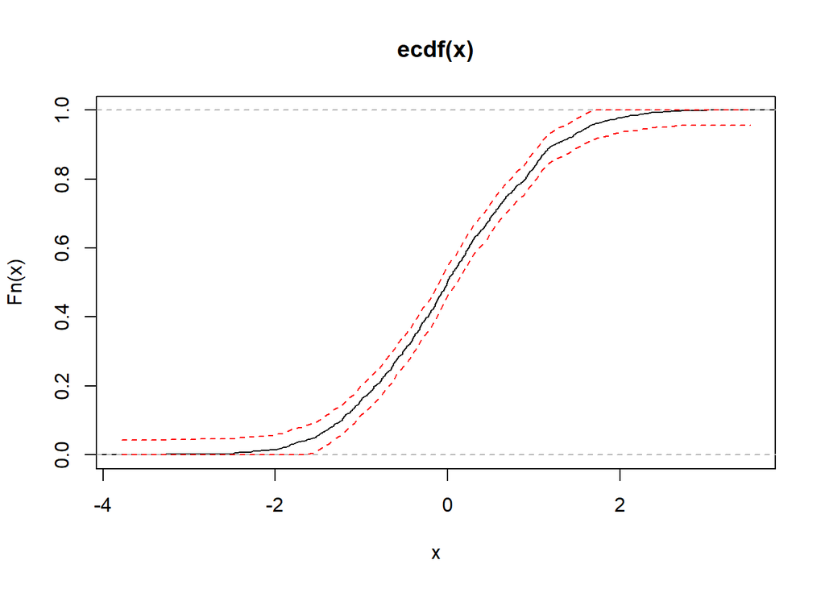

```r
######## Its confidence band (based on DKW theorem)
#DKW 정리(Dvoretzky-Kiefer-Wolfowitz theorem)는
#통계에서 경험적 누적 분포 함수(ECDF)와 모집단의 누적 분포 함수(CDF) 사이의 차이에 대한
#신뢰 구간을 제공하는 중요한 결과.
#이 정리는 주어진 샘플 크기에서 ECDF가 모집단의 진짜 분포와 얼마나 가까운지를 확률적으로 보장해줌

#표준오차와 같은 역할
e<-sqrt(1/(2*n)*log(2/0.05))

L<-function(x){
  pmax(F(x)-e,0)
}

U<-function(x){
  pmin(F(x)+e,1)
}

x11();plot(F)
x11();plot(F, verticals= TRUE, do.points = FALSE)
curve(U, lty=2,add=TRUE,col="red") #상한 값
curve(L, lty=2,add=TRUE,col="red") #하한 값
```

```r
##################################################
### Example: calculating se for median
set.seed(1201)
data<-rnorm(100,5,3)
mean(data)
```

```
## [1] 5.030808
```

```r
sd(data)
```

```
## [1] 2.802445
```

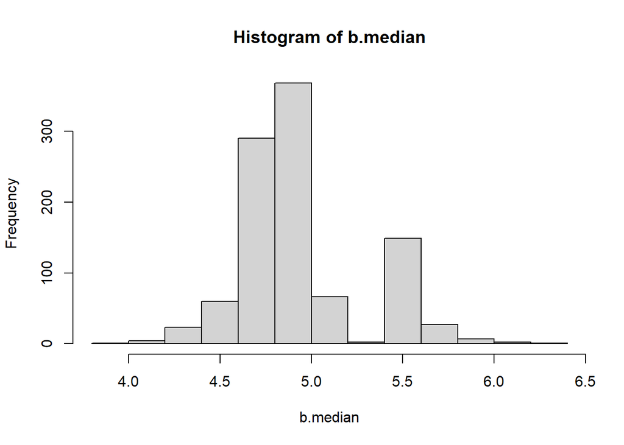

```
## [1] 0.3261566
```

```r
#평균이 5, 표준편차가 3인 정규분포 난수를 100개 생성
#생성된 자료에서 부스트랩 1000번 시행해서, 1000개의 부스트랩 데이터 생성, 반복 허용
#각 1000개 추출된 데이터의 중앙값 계산
B<-1000
b.samples<-lapply(1:B,function(i) sample(data,replace=T))
b.median <-sapply(b.samples,median)

#각 표본 데이터에서 추출된 자료의 중앙값 분포
x11();hist(b.median)

#중앙값에 대한 표준편차
sqrt(var(b.median))
```

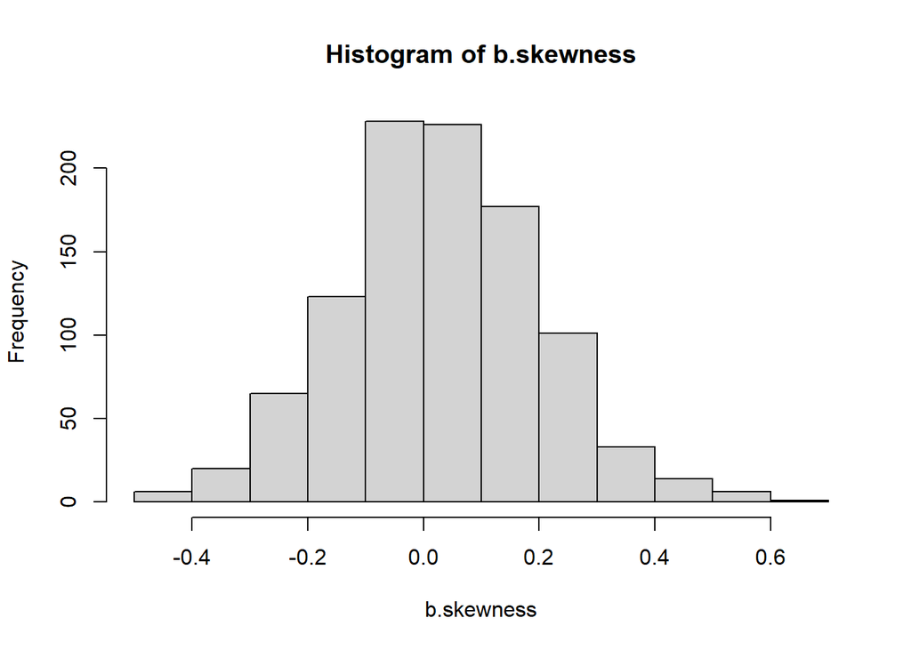

```
## [1] 0.1709833
```

```r
## in theory,
## p*(1-p)/(n*f(5)^2)=1/(100*4*f(5)^2)=0.1414  (f(5)=dnorm(0,0,3))
## sqrt(0.1414)=0.376

##################################################

### Example: calculating se for skewness
library(moments)
set.seed(1201)
data<-rnorm(100,5,3)

B<-1000
b.samples <-lapply(1:B,function(i) sample(data,replace=T))
b.skewness<-sapply(b.samples,skewness)


x11();hist(b.skewness) #기본적으로 3이 기준임
sqrt(var(b.skewness))
```

```r
##################################################

library(boot)
data(bigcity)
head(bigcity)
```

```
##     u   x
## 1 138 143
## 2  93 104
## 3  61  69
## 4 179 260
## 5  48  75
## 6  37  63
```

```r
str(bigcity) #49, 2
```

```
## 'data.frame':    49 obs. of  2 variables:
##  $ u: num  138 93 61 179 48 37 29 23 30 2 ...
##  $ x: num  143 104 69 260 75 63 50 48 111 50 ...
```

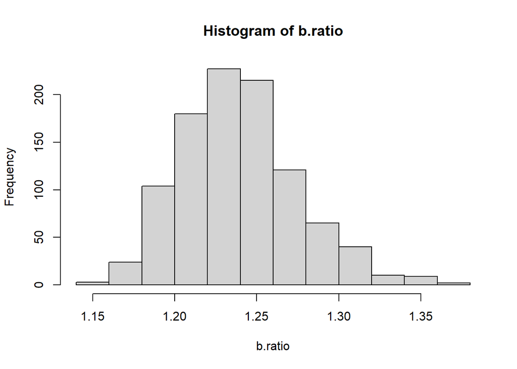

```
## [1] 1.237281
```

```r
## we want to know the mean ratio of the populations,
## i.e. pop 1930/pop 1920
# u: The 1920 population
# x: The 1930 population

row.bigcity<-dim(bigcity)[1]

boots.bigcity<-function(index){
  b.bigcity<-bigcity[index,] #indexing해서 찾아내기 (부스트랩시 샘플 인덱싱)
  b.ratio<-sum(b.bigcity$x)/sum(b.bigcity$u)
  return(b.ratio)
}

B<-1000
b.samples<-lapply(1:B,function(i) sample(c(1:row.bigcity),replace=T))
b.ratio  <-sapply(b.samples,boots.bigcity)

x11();hist(b.ratio)
median(b.ratio)
```

```r
sqrt(var(b.ratio))
```

```
## [1] 0.03571711
```

```r
#### As an alternative, you may use "boot".
#### Before calling boot,
#### you need to define a function that will return the statistic
#### that you want to bootstrap.

library(boot)
ratio <- function(d, indices) sum(d$x[indices])/sum(d$u[indices])
RES.city<-boot(bigcity, ratio, R = 999)
```

*norm: 부트스트랩 표본의 분포가 정규분포가 따를것이라고 가정; 정규분포가 이닐경우 정확하지 않을 수 있음* basic: 부트스트랩 추정치의 중심에서 원래 추정치를 대칭적으로 조정 (대칭 신뢰구간); 분포가 비대칭이면 별로 *per: percentile이용, 부트스트랩 표본에서 직접적으로 신뢰구간을 추정하는 방법; 비대칭 분포에 유리 (대칭성에 의존하지 않음)* bca (Bias-Corrected and Accelerated): 부트스트랩 신뢰구간 중 가장 발전된 방법: 편향과 분포 비대칭성 보정함; 계산이 복잡하고, 작은 샘플에서 부정확할 수 있음

```r
boot.ci(RES.city,type=c("norm","basic","perc","bca"))
```

```
## BOOTSTRAP CONFIDENCE INTERVAL CALCULATIONS
## Based on 999 bootstrap replicates
##
## CALL :
## boot.ci(boot.out = RES.city, type = c("norm", "basic", "perc",
##     "bca"))
##
## Intervals :
## Level      Normal              Basic
## 95%   ( 1.169,  1.309 )   ( 1.164,  1.299 )
##
## Level     Percentile            BCa
## 95%   ( 1.179,  1.314 )   ( 1.181,  1.318 )
## Calculations and Intervals on Original Scale
```

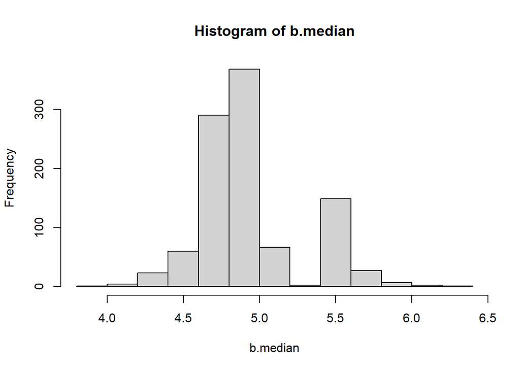

```r
############################################################
#### Bootstrap confidence interval

### Example: calculating se for median
set.seed(1201)
data<-rnorm(100,5,3)

B<-1000
b.samples<-lapply(1:B,function(i) sample(data,replace=T))
b.median<-sapply(b.samples,median)


hist(b.median)
```

```r
sqrt(var(b.median))
```

```
## [1] 0.3261566
```

```r
#아래는 직접 손으로 계산할 떄 예시임
### normal interval
c(mean(b.median)-2*sqrt(var(b.median)),mean(b.median)+2*sqrt(var(b.median)))
```

```
## [1] 4.283448 5.588075
```

```r
### percentile interval
c(quantile(b.median,0.025),quantile(b.median,0.975))
```

```
##     2.5%    97.5%
## 4.380855 5.680970
```

```r
### basic interval
c(2*median(data)-quantile(b.median,0.975),2*median(data)-quantile(b.median,0.025))
```

```
##    97.5%     2.5%
## 4.021430 5.321545
```